# R Notebook

```r
library(tidyverse)
library(RSQLite)
library(dbplyr)
library(janitor)
library(lubridate)
library(datasets)
library(ggthemes)
```

# 1. Data Cleaning

#### Creating connection to the sqlite database and downloading fires dataset

```r
# Connecting

conn <- dbConnect(SQLite(), 'raw_data/FPA_FOD_20170508.sqlite')
```

```r
as.data.frame(dbListTables(conn))
```

| dbListTables(conn) |
| --- |
| ElementaryGeometries |
| Fires |
| KNN |
| NWCG_UnitIDActive_20170109 |
| SpatialIndex |
| geom_cols_ref_sys |
| geometry_columns |
| geometry_columns_auth |
| geometry_columns_field_infos |
| geometry_columns_statistics |

[output cut: 23 more lines]

```r
# Making fires dataframe

fires <- tbl(conn, "Fires") %>% collect()
```

#### Seeing what other useful information is in the database. The majority are part of the database structure and are not readable in R.

```r
tm(spatial_index)
```

[output not shown]

```r
# Disconnect

dbDisconnect(conn)
```

### Selecting columns of interest

```r
fires_small <- fires %>%
  select(NWCG_REPORTING_AGENCY, SOURCE_REPORTING_UNIT_NAME, FIRE_NAME,
         FIRE_YEAR, DISCOVERY_DATE, DISCOVERY_DOY, DISCOVERY_TIME, CONT_DATE,
         CONT_DOY, CONT_TIME, STAT_CAUSE_CODE, STAT_CAUSE_DESCR, FIRE_SIZE,
         FIRE_SIZE_CLASS, LATITUDE, LONGITUDE, OWNER_CODE, OWNER_DESCR, STATE,
         COUNTY, FIPS_CODE, FIPS_NAME, Shape)

fires_small <- clean_names(fires_small)
```

### Changing some columms to be factors

```r
fires_small <- fires_small %>%
  mutate(nwcg_reporting_agency = as.factor(nwcg_reporting_agency)) %>%
  mutate(stat_cause_code = as.factor(stat_cause_code)) %>%
  mutate(fire_size_class = as.factor(fire_size_class)) %>%
  mutate(owner_descr = as.factor(owner_descr)) %>%
  mutate(state = as.factor(state))
```

### Date is in Julian format, so overwriting with Gregorian format using year and day of year columns. Also adding in a ‘month of year column’ for future use.

```r
fires_small <- fires_small %>%
  mutate(date_origin = as.Date(paste0(fire_year, "-01-01"))) %>%
  mutate(discovery_date = as.Date(discovery_doy, origin = date_origin)) %>%
  mutate(discovery_moy = month(discovery_date)) %>%
  select(-date_origin)
```

# 2. Creating some initial visualisations

### Fires per year

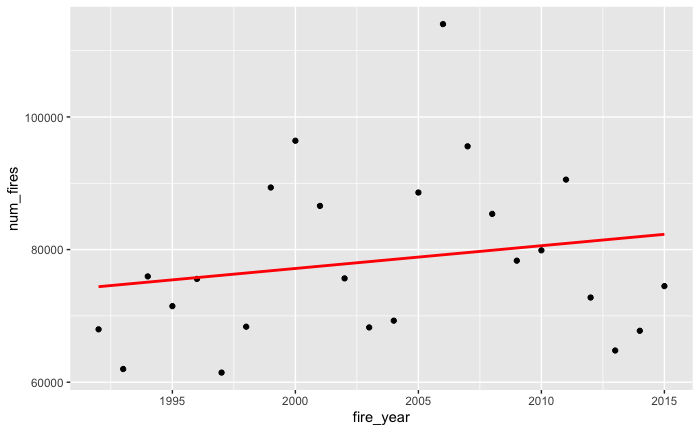

```r
fires_small %>%
  group_by(fire_year) %>%
  summarise(num_fires =n()) %>%
  ggplot +
  aes(x = fire_year, y = num_fires) +
  geom_point() +
  # geom_col(fill = "dark blue", col ="white") +
  geom_smooth(method = 'lm', se = FALSE, colour = "red")
```

**It can be seen from the linear modelling smoother that there is a slight increase of wildfire over the recording period, but there is a lot of variation in the data between years. There is almost a repeating pattern occurring with 4 peaks visible. Having looked at the historic weather for that date range these peaks seems to coincide with recorded heatwaves in 2000, 2006 and 2011.**

### Fires per day

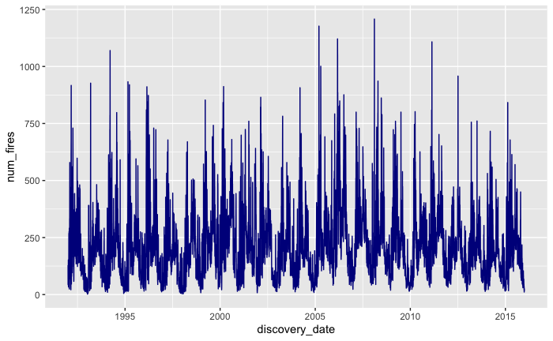

```r
fires_small %>%
  group_by(discovery_date) %>%
  summarise(num_fires = n()) %>%
  ggplot +
  aes(x = discovery_date, y = num_fires) +
  geom_line(col = "dark blue")
```

**This shows a typical time series plot with a cyclic variation due to warmer weather in the summer time.**

### Fires per month

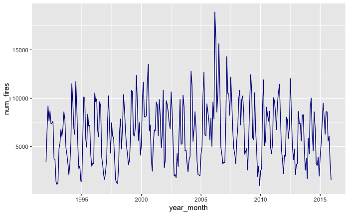

```r
fires_small %>%
  mutate(year_month = make_date(fire_year, discovery_moy)) %>%
  group_by(year_month) %>%
  summarise(num_fires = n()) %>%
  ggplot +
  aes(x = year_month, y = num_fires) +
  geom_line(col = "dark blue")
```

**Peaks are still shown to be occurring in the summer. The 2006 heatwave is especially visable.**

### Fires by day of year

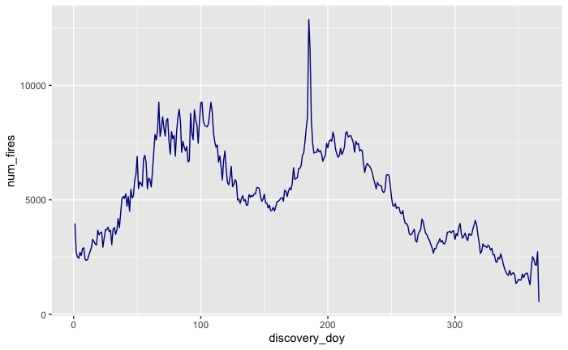

```r
fires_small %>%
  group_by(discovery_doy) %>%
  summarise(num_fires = n()) %>%
  ggplot(aes(x = discovery_doy, y = num_fires)) +
  geom_line(col = "dark blue")
```

**The are peaks around day 60-110 and a big peak around 180.**

#### Checking the data to see where the peak occurs

```r
fires_small %>%
  group_by(discovery_doy) %>%
  summarise(num_fires = n()) %>%
  arrange(desc(num_fires))
```

| discovery_doy | num_fires |
| --- | --- |
| 185 | 12875 |
| 186 | 11535 |
| 101 | 9261 |
| 67 | 9260 |
| 108 | 9256 |
| 100 | 9248 |
| 83 | 8949 |
| 95 | 8924 |
| 109 | 8850 |
| 107 | 8787 |

[output cut: 356 more lines]

### Fires by month of year

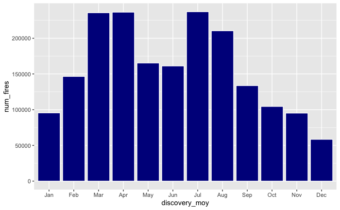

```r
fires_small %>%
  mutate(discovery_moy = (month(ymd(discovery_date), label = TRUE))) %>%
  group_by(discovery_moy) %>%
  summarise(num_fires = n()) %>%
  ggplot(aes(x = discovery_moy, y = num_fires)) +
  geom_col(fill = "dark blue", col = "white")
```

**There are 2 definite peaks during the year. March and April are probably due to the US “Spring Break”, where schools and Universities are stopped and so families are likely to be on vacation during that period possibly visiting National Parks. July and August is also Summer Break for school with both families visiting Parks and hot weather likey causes of fire outbreaks.**

### Fires by cause

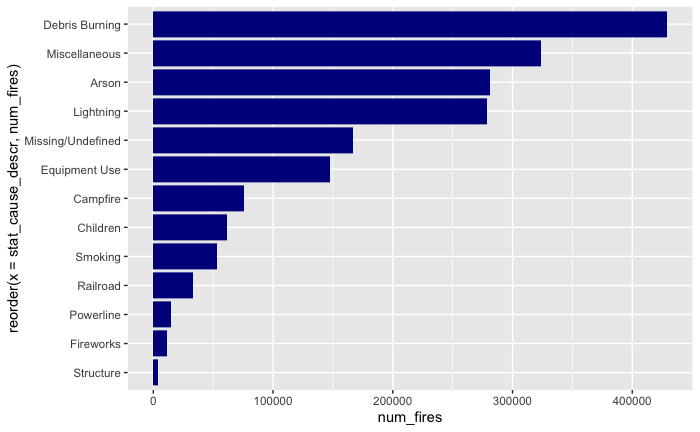

```r
options(scipen = 999)

fires_small %>%
  group_by(stat_cause_descr) %>%
  summarise(num_fires = n()) %>%
  ggplot +
  aes(reorder(x = stat_cause_descr, num_fires), y = num_fires) +
  geom_col(fill = "dark blue") +
  coord_flip()
```

### Fire avg size by cause

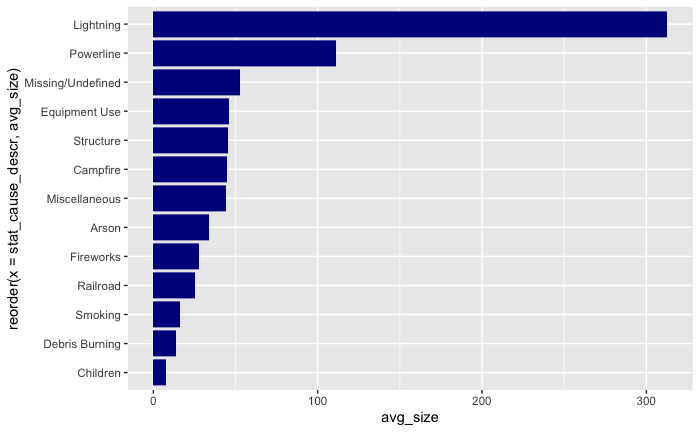

```r
fires_small %>%
  group_by(stat_cause_descr) %>%
  summarise(avg_size = mean(fire_size)) %>%
  ggplot +
  aes(reorder(x = stat_cause_descr, avg_size), y = avg_size) +
  geom_col(fill = "dark blue") +
  coord_flip()
```

### Avg burn time by cause

```r
fires_small %>%
  summarise(num_na = sum(is.na(cont_date)))
```

| num_na |
| --- |
| 891531 |

*Literally half the data is missing for burn time, making it very difficult to do any meaningful analysis*

### Fires by size

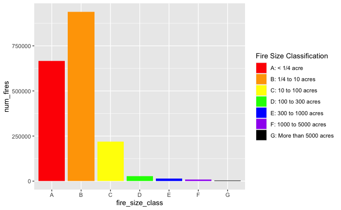

```r
fires_small %>%
  group_by(fire_size_class) %>%
  summarise(num_fires = n()) %>%
  ggplot +
  aes(x = fire_size_class, y = num_fires, fill = fire_size_class) +
  geom_col() +
  scale_fill_manual(values = c("red", "orange", "yellow", "green", "blue",
                               "purple", "black"),
                    name = "Fire Size Classification",
                    breaks = c("A", "B", "C", "D", "E", "F", "G"),
                    labels = c("A: < 1/4 acre", "B: 1/4 to 10 acres", "C: 10 to 100 acres",
                               "D: 100 to 300 acres", "E: 300 to 1000 acres",
                               "F: 1000 to 5000 acres", "G: More than 5000 acres"))
```

# Geo Spatial wrangling

### To make it easier to visually detect frequency of wildfires between states I want display it in a map format. As I’m using ggplot2 already I’m going to also use it for maps with the `geom_polygon()`, `coord_map()` along with the ggthemes `theme_map()` functions.

#### I’m not entirely sure what geo-spatial information is being held with in the sqlite database file, I’ve made a few attempts to retrieve it but have been unsuccessful. Therefore I’m going to utelise the `datasets` package which includes various bits of information on the US States, including coordinates for state boundaries.

```r
# State boundary co-ordinates from 'datasets' package

state_map <- map_data("state")
state_map
```

|  | long | lat | group | order | region | subregion |
| --- | --- | --- | --- | --- | --- | --- |
| 1 | -87.46201 | 30.38968 | 1 | 1 | alabama | NA |
| 2 | -87.48493 | 30.37249 | 1 | 2 | alabama | NA |
| 3 | -87.52503 | 30.37249 | 1 | 3 | alabama | NA |
| 4 | -87.53076 | 30.33239 | 1 | 4 | alabama | NA |
| 5 | -87.57087 | 30.32665 | 1 | 5 | alabama | NA |
| 6 | -87.58806 | 30.32665 | 1 | 6 | alabama | NA |
| 7 | -87.59379 | 30.30947 | 1 | 7 | alabama | NA |
| 8 | -87.59379 | 30.28655 | 1 | 8 | alabama | NA |
| 9 | -87.67400 | 30.27509 | 1 | 9 | alabama | NA |
| 10 | -87.81152 | 30.25790 | 1 | 10 | alabama | NA |

[output cut: 990 more lines]

#### Annoyingly it doesn’t have the abbreviation of the State, only the full name so I need to add that in. Luckily the ‘datasets’ package also has a vector of States names and abbreviations so I shall make a tibble with them both in.

```r
state.abb
```

```
 [1] "AL" "AK" "AZ" "AR" "CA" "CO" "CT" "DE" "FL" "GA" "HI" "ID" "IL" "IN" "IA" "KS"
[17] "KY" "LA" "ME" "MD" "MA" "MI" "MN" "MS" "MO" "MT" "NE" "NV" "NH" "NJ" "NM" "NY"
[33] "NC" "ND" "OH" "OK" "OR" "PA" "RI" "SC" "SD" "TN" "TX" "UT" "VT" "VA" "WA" "WV"
[49] "WI" "WY"
```

```r
state.name
```

```
 [1] "Alabama"        "Alaska"         "Arizona"        "Arkansas"
 [5] "California"     "Colorado"       "Connecticut"    "Delaware"
 [9] "Florida"        "Georgia"        "Hawaii"         "Idaho"
[13] "Illinois"       "Indiana"        "Iowa"           "Kansas"
[17] "Kentucky"       "Louisiana"      "Maine"          "Maryland"
[21] "Massachusetts"  "Michigan"       "Minnesota"      "Mississippi"
[25] "Missouri"       "Montana"        "Nebraska"       "Nevada"
[29] "New Hampshire"  "New Jersey"     "New Mexico"     "New York"
[33] "North Carolina" "North Dakota"   "Ohio"           "Oklahoma"
[37] "Oregon"         "Pennsylvania"   "Rhode Island"   "South Carolina"
[41] "South Dakota"   "Tennessee"      "Texas"          "Utah"
[45] "Vermont"        "Virginia"       "Washington"     "West Virginia"
[49] "Wisconsin"      "Wyoming"
```

```r
state_list <- tibble(state = state.abb, state_name = state.name)
state_list
```

| state | state_name |
| --- | --- |
| AL | Alabama |
| AK | Alaska |
| AZ | Arizona |
| AR | Arkansas |
| CA | California |
| CO | Colorado |
| CT | Connecticut |
| DE | Delaware |
| FL | Florida |
| GA | Georgia |

[output cut: 40 more lines]

#### The `state_map` dataframe is in lower case and has the column name ‘region’. I shall change the `state_list` tibble to be the same format so they can be joined together.

```r
state_list <- tibble(state = state.abb, region = tolower(state.name))
```

#### Joing `state_list` to `fires_small` datasets

```r
fires_states <- fires_small %>%
  left_join(state_list, by = "state")

fires_states
```

| nwcg_reporting_agency | source_reporting_unit_name | fire_name | fire_year | discovery_date | discovery_doy | discovery_time | cont_date | cont_doy | cont_time | stat_cause_code | stat_cause_descr | fire_size | fire_size_class | latitude | longitude | owner_code | owner_descr | state | county | fips_code | fips_name | shape | discovery_moy | region |
| --- | --- | --- | --- | --- | --- | --- | --- | --- | --- | --- | --- | --- | --- | --- | --- | --- | --- | --- | --- | --- | --- | --- | --- | --- |
| FS | Plumas National Forest | FOUNTAIN | 2005 | 2005-02-03 | 33 | 1300 | 2453404 | 33 | 1730 | 9 | Miscellaneous | 0.10 | A | 40.03694 | -121.00583 | 5 | USFS | CA | 63 | 063 | Plumas |  | 2 | california |
| FS | Eldorado National Forest | PIGEON | 2004 | 2004-05-13 | 133 | 0845 | 2453138 | 133 | 1530 | 1 | Lightning | 0.25 | A | 38.93306 | -120.40444 | 5 | USFS | CA | 61 | 061 | Placer |  | 5 | california |
| FS | Eldorado National Forest | SLACK | 2004 | 2004-06-01 | 152 | 1921 | 2453156 | 152 | 2024 | 5 | Debris Burning | 0.10 | A | 38.98417 | -120.73556 | 13 | STATE OR PRIVATE | CA | 17 | 017 | El Dorado |  | 6 | california |
| FS | Eldorado National Forest | DEER | 2004 | 2004-06-29 | 180 | 1600 | 2453190 | 185 | 1400 | 1 | Lightning | 0.10 | A | 38.55917 | -119.91333 | 5 | USFS | CA | 3 | 003 | Alpine |  | 6 | california |
| FS | Eldorado National Forest | STEVENOT | 2004 | 2004-06-29 | 180 | 1600 | 2453190 | 185 | 1200 | 1 | Lightning | 0.10 | A | 38.55917 | -119.93306 | 5 | USFS | CA | 3 | 003 | Alpine |  | 6 | california |
| FS | Eldorado National Forest | HIDDEN | 2004 | 2004-07-01 | 182 | 1800 | 2453188 | 183 | 1600 | 1 | Lightning | 0.10 | A | 38.63528 | -120.10361 | 5 | USFS | CA | 5 | 005 | Amador |  | 7 | california |
| FS | Eldorado National Forest | FORK | 2004 | 2004-07-02 | 183 | 1800 | 2453188 | 184 | 1400 | 1 | Lightning | 0.10 | A | 38.68833 | -120.15333 | 5 | USFS | CA | 17 | 017 | El Dorado |  | 7 | california |
| FS | Shasta-Trinity National Forest | SLATE | 2005 | 2005-03-09 | 67 | 1300 | 2453438 | 67 | 1600 | 5 | Debris Burning | 0.80 | B | 40.96806 | -122.43389 | 13 | STATE OR PRIVATE | CA | NA | NA | NA |  | 3 | california |
| FS | Shasta-Trinity National Forest | SHASTA | 2005 | 2005-03-16 | 74 | 1200 | 2453444 | 74 | 1700 | 5 | Debris Burning | 1.00 | B | 41.23361 | -122.28333 | 13 | STATE OR PRIVATE | CA | NA | NA | NA |  | 3 | california |
| FS | Eldorado National Forest | TANGLEFOOT | 2004 | 2004-07-02 | 183 | 1800 | 2453188 | 184 | 1800 | 1 | Lightning | 0.10 | A | 38.54833 | -120.14917 | 5 | USFS | CA | 5 | 005 | Amador |  | 7 | california |

[output cut: 990 more lines]

#### Checking the join has worked and there are no missing values.

```r
fires_states %>%
  filter(is.na(region))
```

| nwcg_reporting_agency | source_reporting_unit_name | fire_name | fire_year | discovery_date | discovery_doy | discovery_time | cont_date | cont_doy | cont_time | stat_cause_code | stat_cause_descr | fire_size | fire_size_class | latitude | longitude | owner_code | owner_descr | state | county | fips_code | fips_name | shape | discovery_moy | region |
| --- | --- | --- | --- | --- | --- | --- | --- | --- | --- | --- | --- | --- | --- | --- | --- | --- | --- | --- | --- | --- | --- | --- | --- | --- |
| NPS | National Capitol Parks - East | FT.CHAPLIN | 1999 | 1999-06-09 | 159 | 1500 | 2451338 | 159 | 2230 | 9 | Miscellaneous | 0.10 | A | 38.88669 | -76.94510 | 3 | NPS | DC | NA | NA | NA |  | 6 | NA |
| NPS | National Capitol Parks - East | WATTSB | 1999 | 1999-07-16 | 196 | 2130 | NA | NA | NA | 9 | Miscellaneous | 0.10 | A | 38.91193 | -76.94274 | 3 | NPS | DC | NA | NA | NA |  | 7 | NA |
| NPS | National Capitol Parks - East | FTCHAPLIN2 | 1999 | 1999-08-04 | 215 | 1300 | 2451394 | 216 | 2359 | 9 | Miscellaneous | 0.10 | A | 38.88670 | -76.94531 | 3 | NPS | DC | NA | NA | NA |  | 8 | NA |
| NPS | National Capitol Parks - East | DOUGLASS | 1999 | 1999-08-18 | 229 | 1530 | 2451408 | 229 | 1715 | 9 | Miscellaneous | 0.10 | A | 38.86260 | -76.98591 | 3 | NPS | DC | NA | NA | NA |  | 8 | NA |
| NPS | Rock Creek Park | GROVE 29 | 1992 | 1992-02-12 | 42 | 1605 | 2448664 | 42 | 1634 | 7 | Arson | 0.20 | A | 38.93832 | -77.03740 | 3 | NPS | DC | NA | NA | NA |  | 2 | NA |
| NPS | Rock Creek Park | FT SLOCUM | 1992 | 1992-07-22 | 203 | 0900 | 2448824 | 203 | 0930 | 7 | Arson | 0.10 | A | 38.95916 | -77.01434 | 3 | NPS | DC | NA | NA | NA |  | 7 | NA |
| NPS | Rock Creek Park | FT.TOTTEN | 1993 | 1993-02-06 | 36 | 1156 | 2449024 | 36 | 1230 | 7 | Arson | 0.30 | B | 38.94837 | -77.00484 | 3 | NPS | DC | NA | NA | NA |  | 2 | NA |
| NPS | Rock Creek Park | BUNKERHILL | 1993 | 1993-02-06 | 36 | 1400 | 2449024 | 36 | 1530 | 7 | Arson | 0.70 | B | 38.93587 | -76.98837 | 3 | NPS | DC | NA | NA | NA |  | 2 | NA |
| NPS | Rock Creek Park | PIERCE MIL | 1993 | 1993-05-03 | 122 | NA | 2449110 | 122 | NA | 7 | Arson | 1.00 | B | 38.93330 | -77.05000 | 3 | NPS | DC | NA | NA | NA |  | 5 | NA |
| NPS | Rock Creek Park | BEACH DR | 1993 | 1993-05-03 | 122 | NA | 2449110 | 122 | NA | 7 | Arson | 4.00 | B | 38.93330 | -77.05000 | 3 | NPS | DC | NA | NA | NA |  | 5 | NA |

[output cut: 990 more lines]

#### There does seem to be 22,147 NAs in the ‘region’ column we just made. Scrolling through there are 2 missing States of ‘PR’ and ‘DC’ in the `states_list` tibble.

#### After some quick research it seems that there are only 50 States in the US. Washington DC is techincally not counted as a state but as a Federal District, as it is the seat of government, so that was why it wasn’t included in the `States` tibble originally. PR is Puerto Rico and is also not a state but the largest US territory .

#### I shall add DC and PR into the state_list and re-join it.

```r
# Adding 2 new states

state.abb <- append(state.abb, c("DC", "PR"))
state.name <- append(state.name, c("District of Columbia", "Puerto Rico"))

state_list <- tibble(state = state.abb, region = tolower(state.name))
```

```r
# Re-joing tibbles

fires_states <- fires_small %>%
  left_join(state_list, by = "state")
```

```r
# Checking the join has worked properly and there are no NAs

fires_states %>%
  filter(is.na(region))
```

| nwcg_reporting_agency | source_reporting_unit_name | fire_name | fire_year | discovery_date | discovery_doy | discovery_time | cont_date | cont_doy | cont_time | stat_cause_code | stat_cause_descr | fire_size | fire_size_class | latitude | longitude | owner_code | owner_descr | state | county | fips_code | fips_name | shape | discovery_moy | region |
| --- | --- | --- | --- | --- | --- | --- | --- | --- | --- | --- | --- | --- | --- | --- | --- | --- | --- | --- | --- | --- | --- | --- | --- | --- |

```r
fires_joined <- fires_states %>%
  right_join(state_map, by = "region")
```

```
Error: vector memory exhausted (limit reached?)
```

#### The data set and geo information is too big to join so I’m going to do a summarise first to get the number of fires per region first.

```r
fires_joined <- fires_states %>%
    select(region) %>%
    group_by(region) %>%
    summarise(num_fires = n()) %>%
    right_join(state_map, by = "region")
```

**Result!! Now doing first geo spatial visualisation**

### Total Wildfires per state from 1992-2015

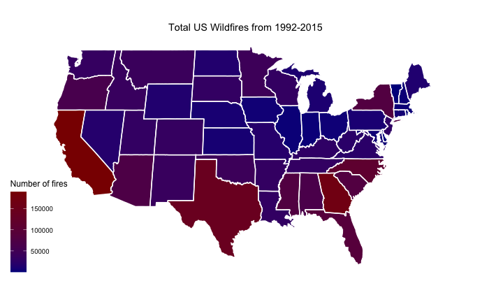

```r
fires_joined %>%
    ggplot +
    (aes(x = long, y = lat, group = group, fill = num_fires)) +
    geom_polygon() +
    geom_path(color = 'white') +
    scale_fill_continuous(low = "darkblue",
                          high = "darkred",
                          name = "Number of fires") +
    theme_map() +
    coord_map("mollweide") +
    ggtitle("Total US Wildfires from 1992-2015") +
    theme(plot.title = element_text(hjust = 0.5))
```

# 3. Geo Spatial Visualisations

### The dataset has a cause of fire column so I shall now create some causation plots.

#### Getting list of fire causes

```r
fires_states %>%
  distinct(stat_cause_descr) %>%
  arrange(-desc(stat_cause_descr))
```

| stat_cause_descr |
| --- |
| Arson |
| Campfire |
| Children |
| Debris Burning |
| Equipment Use |
| Fireworks |
| Lightning |
| Miscellaneous |
| Missing/Undefined |
| Powerline |

[output cut: 3 more lines]

### Total fire by cause in tabular form

```r
fires_states %>%
  select(stat_cause_descr) %>%
  group_by(stat_cause_descr) %>%
  summarise(num_fires = n ()) %>%
  arrange(desc(num_fires))
```

| stat_cause_descr | num_fires |
| --- | --- |
| Debris Burning | 429028 |
| Miscellaneous | 323805 |
| Arson | 281455 |
| Lightning | 278468 |
| Missing/Undefined | 166723 |
| Equipment Use | 147612 |
| Campfire | 76139 |
| Children | 61167 |
| Smoking | 52869 |
| Railroad | 33455 |

[output cut: 3 more lines]

```r
NA
```

### Number of fires by state in tabular form

```r
fires_states %>%
  select(region) %>%
  group_by(region) %>%
  summarise(num_fires = n()) %>%
  arrange(desc(num_fires))
```

| region | num_fires |
| --- | --- |
| california | 189550 |
| georgia | 168867 |
| texas | 142021 |
| north carolina | 111277 |
| florida | 90261 |
| south carolina | 81315 |
| new york | 80870 |
| mississippi | 79230 |
| arizona | 71586 |
| alabama | 66570 |

[output cut: 42 more lines]

#### As the cause needs to be filtered before the map join, I’m going to either going to have to do it in every single plot or write a function that will do it for me with a lot less code in total.

```r
cause <- function(cause) {
  fires_states %>%
    filter(stat_cause_descr == cause) %>%
    select(region) %>%
    group_by(region) %>%
    summarise(num_fires = n ()) %>%
    right_join(state_map, by = "region") %>%
    ggplot +
    (aes(x = long, y = lat, group = group, fill = num_fires)) +
    geom_polygon() +
    geom_path(color = 'white') +
    scale_fill_continuous(low = "darkblue",
                          high = "darkred",
                          name = "Number of fires") +
    theme_map() +
    coord_map("mollweide") +
    ggtitle(paste0("Total US Wildfires caused by ", cause, " from 1992-2015")) +
    theme(plot.title = element_text(hjust = 0.5))
}
```

### Wildfires caused by Arson

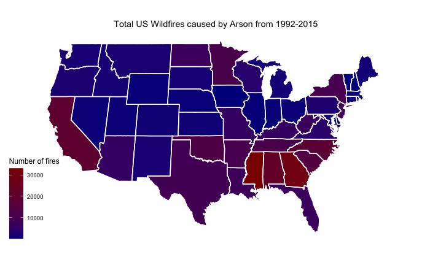

```r
cause("Arson")
```

**Arson does seem more prevalent in the SE states of Mississippi, Georgia, Alabama and also the western state of California.**

### Wildfires caused by Campfire

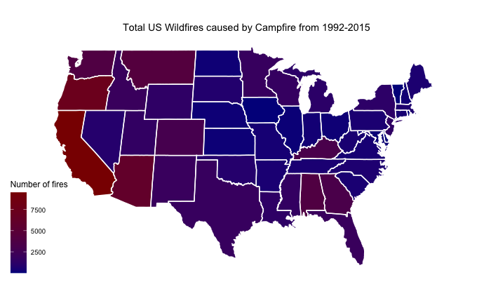

```r
cause("Campfire")
```

**Campfires are the most prevalent in the Western states of Oregon, California and Arizona.**

### Wildfires caused by Children

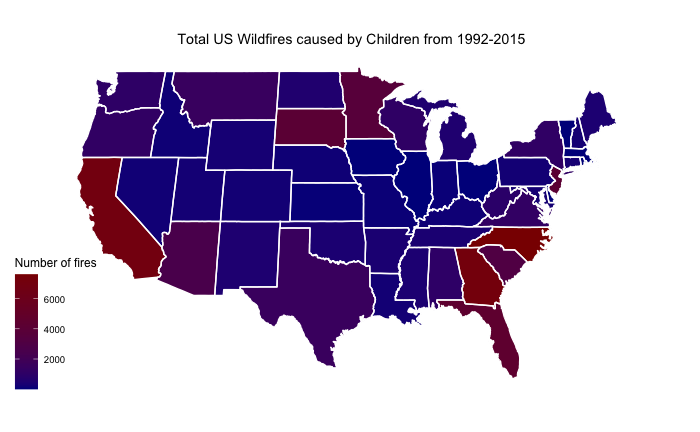

```r
cause("Children")
```

### Wildfires caused by Debris Burning

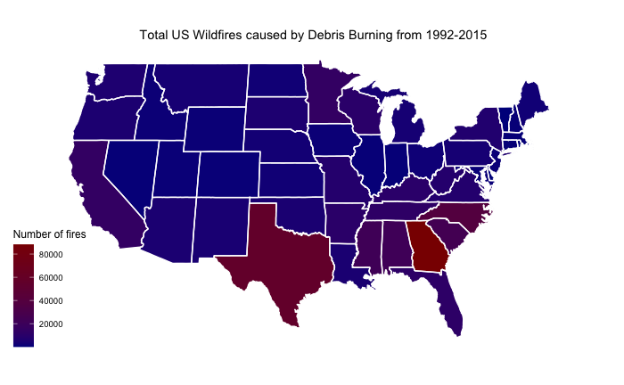

```r
cause("Debris Burning")
```

**Fires by burning debris are mostly in the southern warmer states of Texas, Georgia and North Carolina.**

### Wildfires caused by Equiment Use

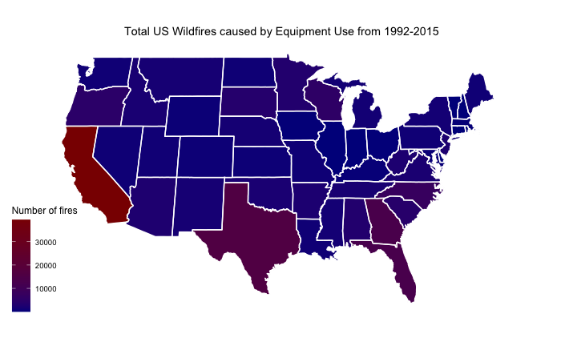

```r
cause("Equipment Use")
```

**Most of the fires caused by equipment seem to be in California**

### Wildfires caused by Fireworks

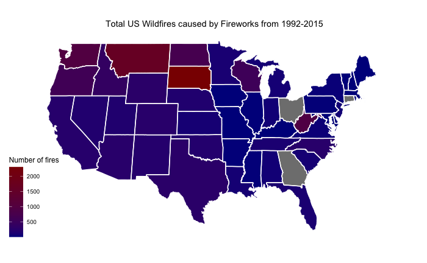

```r
cause("Fireworks")
```

**Most of the fires caused by fireworks seem to be in the north of the country. Primarily South Dakota, Montana and Washington state.**

### Wildfires caused by Lightning

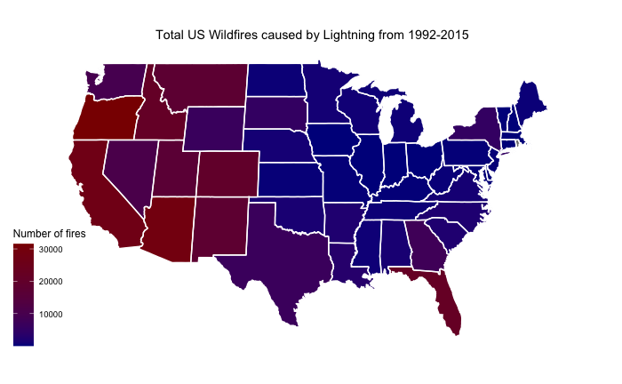

```r
cause("Lightning")
```

**Apart from a hotspot of lightning strikes in Florida, the vast majority of fires caused by lightning are in the West of the country. With the 3 most affected states being California, Oregon and Arizona.**

### Wildfires caused by Miscellious

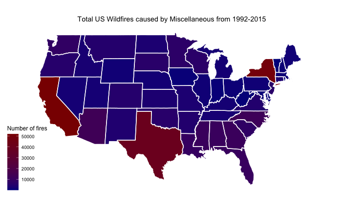

```r
cause("Miscellaneous")
```

**There seems to be quite a few miscellaneous classifications in California, Texas and New York.**

### Wildfires caused by Missing/Undefined

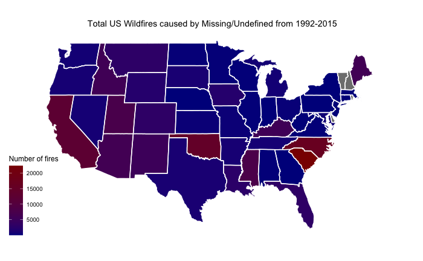

```r
cause("Missing/Undefined")
```

**The states with the most missing or undefined data is North and South Carolina, Oklahoma and California.**

### Wildfires caused by Powerline

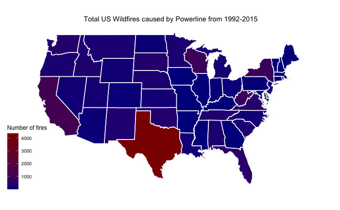

```r
cause("Powerline")
```

**Texas has the largest amount of wildfires caused by powerlines. This is likely due to the warm climate and the large proportion of the state that is dry grasslands used for agriculture.**

### Wildfires caused by Railroad

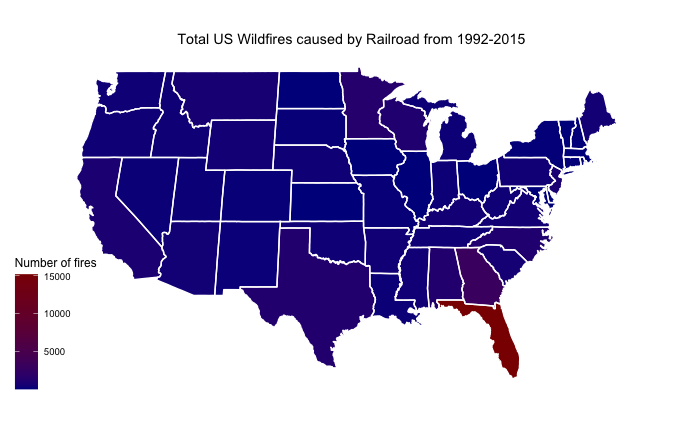

```r
cause("Railroad")
```

**By far Florida has the most wildfires caused by railroads.**

### Wildfires caused by Smoking

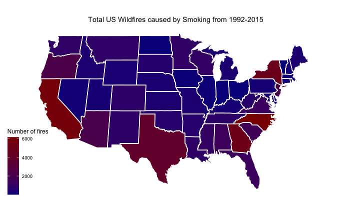

```r
cause("Smoking")
```

**Fires caused by smoking seem to be spread around the country, but mainly on the east and west coasts.**

### Wildfires caused by Structure

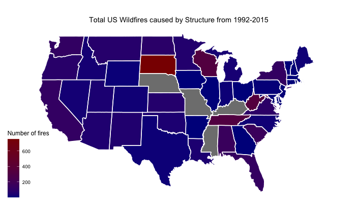

```r
cause("Structure")
```

**South Dakota has the largest proportion of fires caused by structures.**

#### The `dataset` package also has the area in square miles of each state included in the `state.area` vector.

```r
state.area
```

```
 [1]  51609 589757 113909  53104 158693 104247   5009   2057  58560  58876   6450
[12]  83557  56400  36291  56290  82264  40395  48523  33215  10577   8257  58216
[23]  84068  47716  69686 147138  77227 110540   9304   7836 121666  49576  52586
[34]  70665  41222  69919  96981  45333   1214  31055  77047  42244 267339  84916
[45]   9609  40815  68192  24181  56154  97914
```

```r
length(state.area)
```

```
[1] 50
```

#### Annoyingly it also only has 50 states not 52 so I will need to add in DC and PR back in.

(Area figures obtained from Wikipedia)

DC = 68 miles^2 PR = 3515 miles^2

```r
# To make my life easier I'm going to remove the state.abb and .name files and make the tibble again, adding in the land area figures at the same time to make sure they are in the correct order.

rm(state.abb)
rm(state.name)

state.abb <- append(state.abb, c("DC", "PR"))
state.name <- append(state.name, c("District of Columbia", "Puerto Rico"))
state.area <- append(state.area, c("68", "3515"))

state_list <- tibble(state = state.abb, region = tolower(state.name), area = as.numeric(state.area))
```

```r
# Re-joing tibbles

fires_states <- fires_small %>%
  left_join(state_list, by = "state")
```

### Normalising States area sizes

```r
fires_states %>%
  select(region, area) %>%
  group_by(region, area) %>%
  summarise(num_fires = n()) %>%
  mutate(fires_sqmile = num_fires / area) %>%
  arrange(desc(fires_sqmile))
```

| region | area | num_fires | fires_sqmile |
| --- | --- | --- | --- |
| puerto rico | 3515 | 22081 | 6.28193457 |
| new jersey | 7836 | 25949 | 3.31151097 |
| georgia | 58876 | 168867 | 2.86818058 |
| south carolina | 31055 | 81315 | 2.61841893 |
| north carolina | 52586 | 111277 | 2.11609554 |
| mississippi | 47716 | 79230 | 1.66044933 |
| new york | 49576 | 80870 | 1.63123285 |
| florida | 58560 | 90261 | 1.54134221 |
| hawaii | 6450 | 9895 | 1.53410853 |
| alabama | 51609 | 66570 | 1.28989130 |

[output cut: 42 more lines]

#### This table shows Puerto Rico has the highest proportion of fires compared to its size, followed by New Jersey in the NE of the country and finally by the States in the SE of the country.

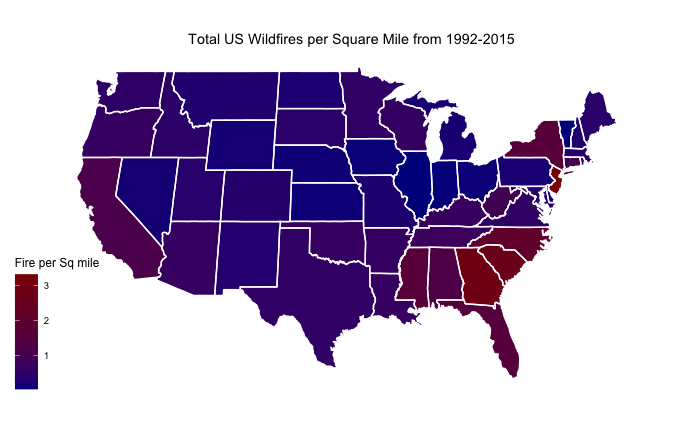

```r
fires_states %>%
  select(region, area) %>%
  group_by(region, area) %>%
  summarise(num_fires = n()) %>%
  mutate(fires_sqmile = num_fires / area) %>%
  right_join(state_map, by = "region") %>%
  ggplot +
  (aes(x = long, y = lat, group = group, fill = fires_sqmile)) +
  geom_polygon() +
  geom_path(color = 'white') +
  scale_fill_continuous(low = "darkblue",
                        high = "darkred",
                        name = "Fire per Sq mile") +
  theme_map() +
  coord_map("mollweide") +
  ggtitle(paste0("Total US Wildfires per Square Mile from 1992-2015")) +
  theme(plot.title = element_text(hjust = 0.5))
```

### Do causes change over time?

#### Splitting causes into 2 group for legibility.

#### The first group is for directly man created fires.

[output not shown]

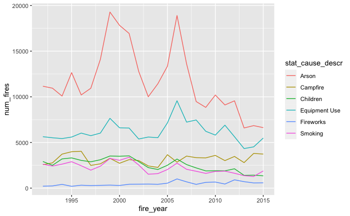

```r
fires_states %>%
  select(stat_cause_descr, fire_year) %>%
  group_by(fire_year, stat_cause_descr) %>%
  filter(stat_cause_descr == "Arson" | stat_cause_descr == "Campfire" |
           stat_cause_descr == "Children" | stat_cause_descr == "Equipment Use" |
           stat_cause_descr == "Fireworks" | stat_cause_descr == "Smoking") %>%
  summarise(num_fires = n()) %>%
  ggplot +
  aes(x = fire_year, y = num_fires, colour = stat_cause_descr) +
  geom_line()
```

**The 2 large peaks in Arson are obvious in 1999 and 2006. There was a large heatwave in 2006, but I’m not sure why this would result in an increase in arson. Unless this was jsut due to the dry ground creating extra fuel to aid the spread of fires that would have normally not resulted in a large scale fire. This may also be the same reason that there is also another peak in 2006 for Equipment Use. Arson however does look to be decreasing since 2006.**

#### And this one for natural occuring fires.

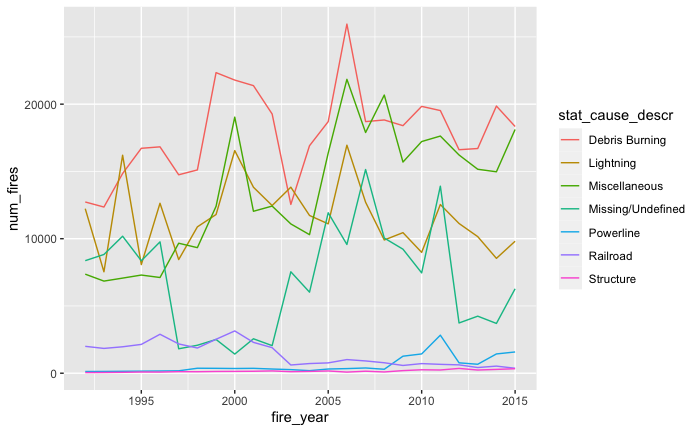

```r
fires_states %>%
  select(stat_cause_descr, fire_year) %>%
  group_by(fire_year, stat_cause_descr) %>%
  filter(stat_cause_descr == "Debris Burning" | stat_cause_descr == "Lightning" |
           stat_cause_descr == "Miscellaneous" | stat_cause_descr ==
           "Missing/Undefined" | stat_cause_descr == "Powerline" |
           stat_cause_descr == "Railroad" | stat_cause_descr == "Structure") %>%
  summarise(num_fires = n()) %>%
  ggplot +
  aes(x = fire_year, y = num_fires, colour = stat_cause_descr) +
  geom_line()
```

**Similar peaks can be seen in Debris, Miscellaneous and lightning in the heatwave of 2006 that left the ground very dry. There are peaks from 1997 to 2003 in debris, miscellaneous and lightening, but also a trough in missing/undefined, so this is likely to be due to more accurate classification of fires and not using the missing/undefined category as much.**